# VIS-Assignment 1

Kristy Henrich

9/9/2020

## Load libraries

```r
library(ggplot2)
library(tidyverse)
library(tidycensus)
library(ggthemes)
```

## Select variables

(I had already created a new dataset before learning I could use my quant one, so I still decided to check out HI tracts.)

Plots 3, 6, and 8-10 draw code and inspiration from Taelor’s assignment. Plots 1-5, 7, and 10 draw code and inspiration from Carole’s assignment.

```r
area_vars_2018 <- load_variables(2018, "acs5")
```

```r
vars <- c("B25001_001",
          "B01002_001",
          "B06011_001",
          "B01003_001",
          "B03002_003",
          "B03002_004",
          "B03002_006",
          "B03002_012",
          "B08006_001",
          "B08006_002",
          "B08006_008",
          "B08006_014",
          "B08006_015",
          "B08006_016",
          "B08006_017",
          "B05002_001",
          "B05002_002",
          "B05002_013")
```

## Develop table

Using my variable selections, I created a HI_tracts table. I looked to Taelor’s code to massage my race and ethnicity data and applied the same structure for other modifications I needed to make to put together the table.

```r
HI_tracts <- get_acs(geography = "tract", variables = vars,
                           state = "HI", output = "wide") %>%
  rename(tot_hh = "B25001_001E",
                    med_age = "B01002_001E",
                    med_income = "B06011_001E",
                    tot_pop = "B01003_001E",
                    nh_white_pop = "B03002_003E",
                    nh_black_pop = "B03002_004E",
                    nh_asian_pop = "B03002_006E",
                    hispanic_pop = "B03002_012E",
                    total_transport = "B08006_001E",
                    transport_car = "B08006_002E",
                    transport_public = "B08006_008E",
                    transport_bicycle = "B08006_014E",
                    transport_walked = "B08006_015E",
                    transport_taxi = "B08006_016E",
                    transport_wfh = "B08006_017E",
                    total_birth = "B05002_001E",
                    birth_native = "B05002_002E",
                    birth_foreign = "B05002_013E") %>%
              mutate(birth_native_foreign = case_when(
                     birth_native / total_birth > 0.5 ~ "native_born",
                     birth_foreign / total_birth > 0.5 ~ "foreign_born",
                     TRUE ~ "None"),
                    majority_race_eth = case_when(
                     nh_white_pop / tot_pop > 0.5 ~ "nh_white",
                     nh_black_pop / tot_pop > 0.5 ~ "nh_black",
                     nh_asian_pop / tot_pop > 0.5 ~ "nh_asian",
                     hispanic_pop / tot_pop > 0.5 ~ "hispanic",
                    (nh_white_pop + nh_black_pop + nh_asian_pop + hispanic_pop) / tot_pop < 0.5 ~ "other",
                     TRUE ~ "None"),
                    majority_transport = case_when(
                     transport_car / total_transport > 0.5 ~ "car",
                     transport_public / total_transport > 0.5 ~ "pub_trans",
                     transport_bicycle / total_transport > 0.5 ~ "bicycle",
                     transport_walked / total_transport > 0.5 ~ "walked",
                     transport_taxi / total_transport > 0.5 ~ "taxi",
                     transport_wfh / total_transport > 0.5 ~ "wfh",
                     TRUE ~ "None")) %>%
            filter(tot_pop > 0, tot_hh > 0) %>%
            select(GEOID, birth_native_foreign, majority_race_eth, majority_transport, tot_pop, med_age, med_income)
```

## Plot 1

Plot 1 shows a scatter plot of the median age by median income within a tract using color to denote the majority mode of transport to work taken by its residents.

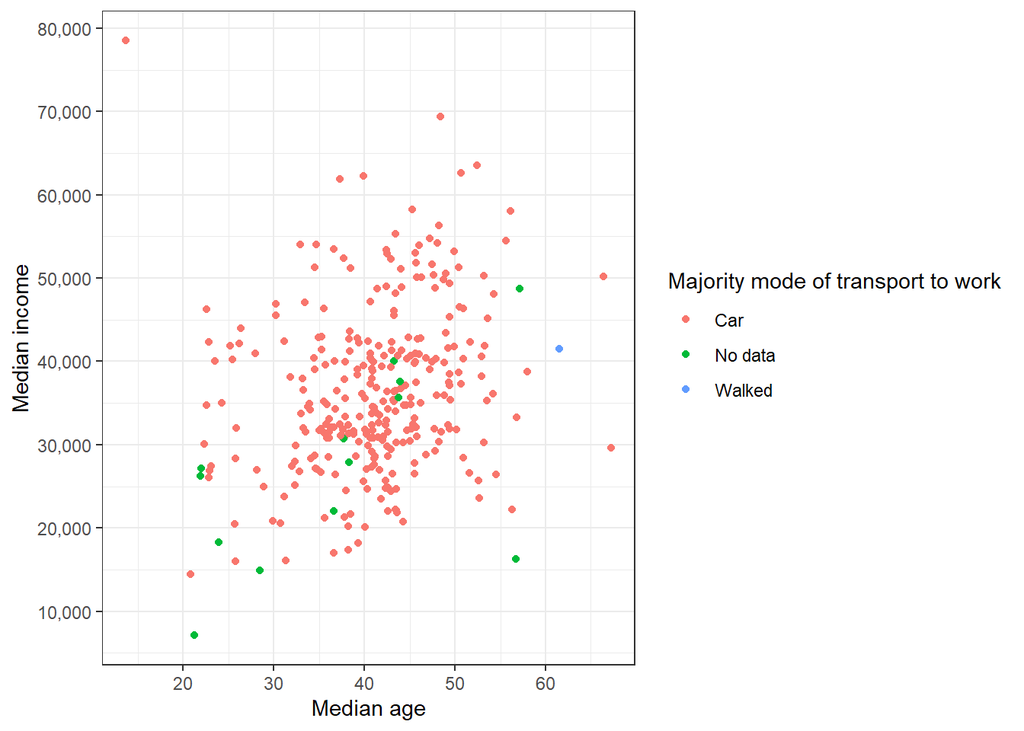

```r
ggplot(HI_tracts,
       aes(x = med_age,
           y = med_income,
           color = majority_transport)) +
  geom_point() +
  scale_x_continuous(name = "Median age",
                     breaks = seq(0, 80, by = 10))+
  scale_y_continuous(labels = scales::comma,
                     name = "Median income",
                     breaks = seq(0, 80000, by = 10000)) +
  scale_color_discrete(name = "Majority mode of transport to work",
                       labels = c("Car",
                                   "No data",
                                   "Walked")) +
  theme_bw()
```

## Plot 2

Plot 2 shows race/ethnicity trends by tract plotted by the median income and total population of that tract as a scatter plot.

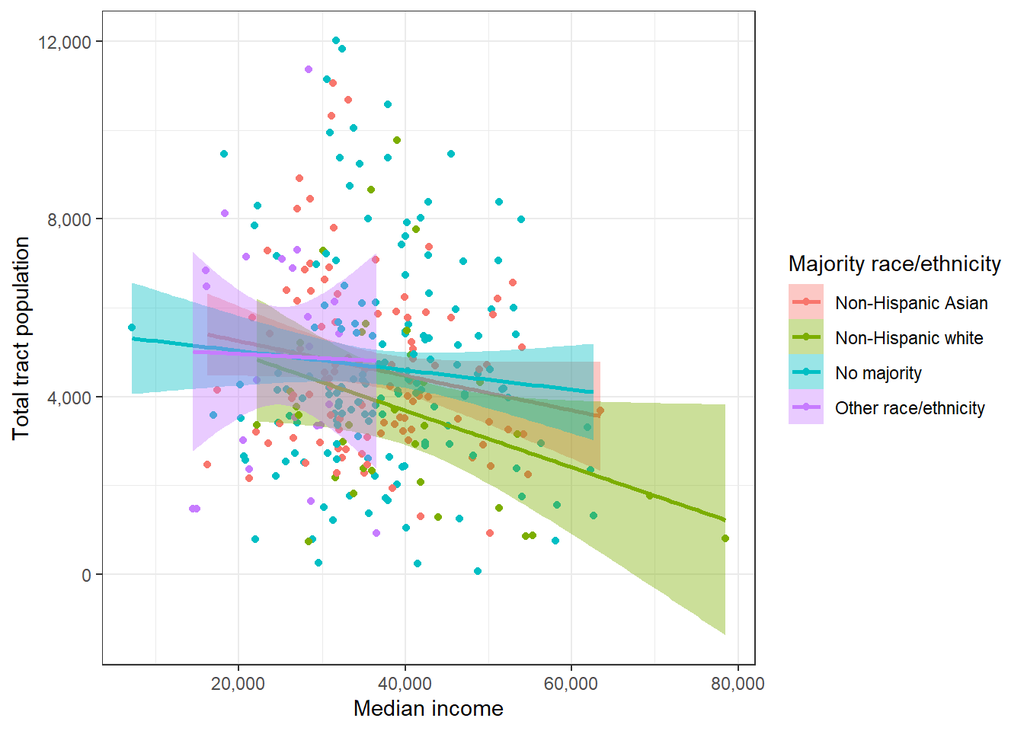

```r
ggplot(HI_tracts,
       aes(x = med_income,
           y = tot_pop,
           color = majority_race_eth,
           fill = majority_race_eth)) +
  geom_point() +
  stat_smooth(method = "lm") +
  scale_x_continuous(labels = scales::comma,
                     name = "Median income",
                     breaks = seq(0, 80000, by = 20000)) +
  scale_y_continuous(labels = scales::comma,
                     name = "Total tract population") +
  scale_color_discrete(name = "Majority race/ethnicity",
                       labels = c("Non-Hispanic Asian",
                                  "Non-Hispanic white",
                                  "No majority",
                                  "Other race/ethnicity" )) +
  scale_fill_discrete(name = "Majority race/ethnicity",
                       labels = c("Non-Hispanic Asian",
                                  "Non-Hispanic white",
                                  "No majority",
                                  "Other race/ethnicity" )) +
  theme_bw()
```

## Plot 3 Plot 3 shows a violin plot of the majority race/ethnicity vs. median age within the tract.

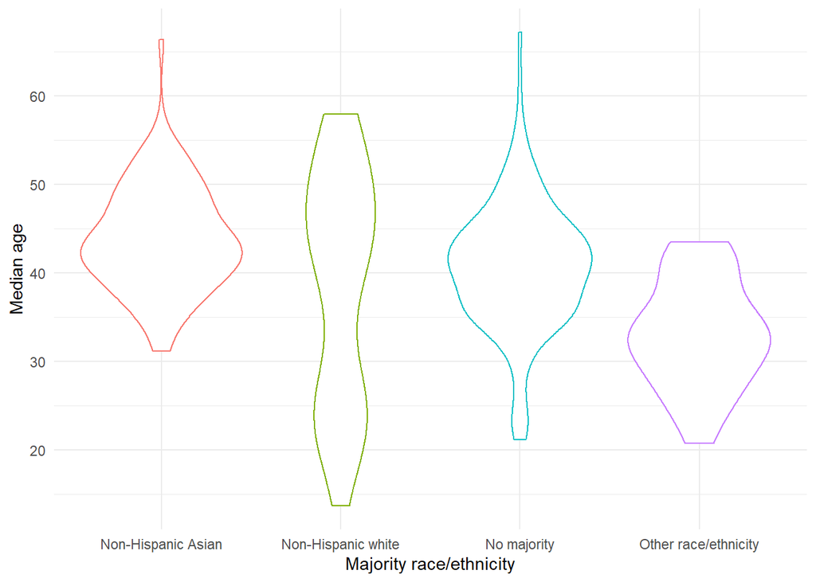

```r
ggplot(HI_tracts,
       aes(x = majority_race_eth,
           y = med_age,
           color = majority_race_eth)) +
  geom_violin() +
  scale_x_discrete(name = "Majority race/ethnicity",
                       labels = c("Non-Hispanic Asian",
                                  "Non-Hispanic white",
                                  "No majority",
                                  "Other race/ethnicity")) +
  scale_y_continuous(name = "Median age",
                     breaks = seq(10, 80, by = 10)) +
  theme_minimal() +
  theme(legend.position = "none")
```

## Plot 4

Plot 4 shows a stacked bar chart of the number of tracts by majority race/ethnicity that have a majority foreign vs. native born population.

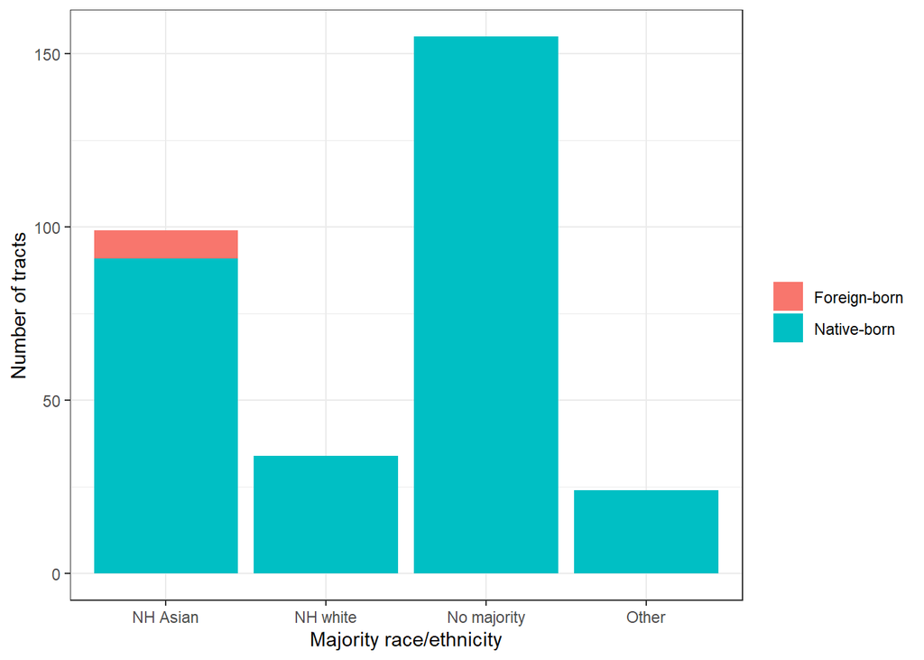

```r
ggplot(HI_tracts, aes(x = majority_race_eth, fill = birth_native_foreign)) +
  geom_bar() +
  scale_y_continuous(name = "Number of tracts") +
  scale_x_discrete(name = "Majority race/ethnicity",
                       labels = c("NH Asian",
                                  "NH white",
                                  "No majority",
                                  "Other")) +
  scale_fill_discrete(name = element_blank(),
                        labels = c("Foreign-born",
                                   "Native-born")) +
  theme_bw()
```

## Plot 5

Plot 5 shows a box plot of the median age in tracts broken out by a tract’s population being majority native vs. foreign-born

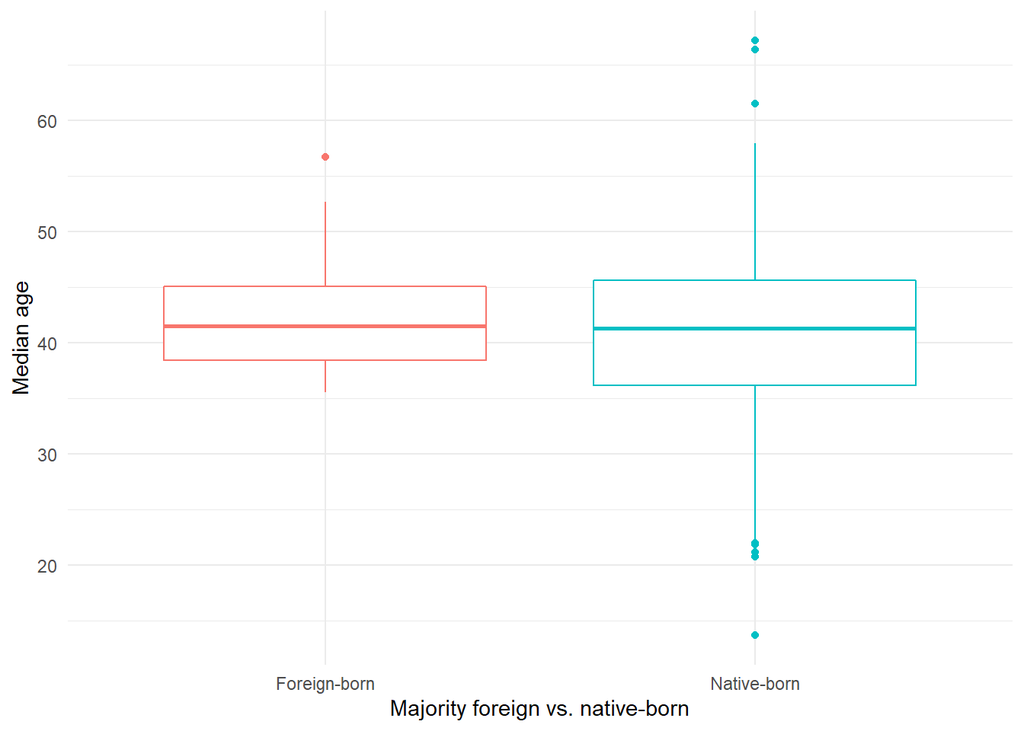

```r
ggplot(HI_tracts,
       aes(x = birth_native_foreign,
           y = med_age,
           color = birth_native_foreign)) +
  geom_boxplot() +
  scale_x_discrete(name = "Majority foreign vs. native-born",
                       labels = c("Foreign-born",
                                  "Native-born")) +
  scale_y_continuous(name = "Median age",
                     breaks = seq(10, 80, by = 10)) +
  theme_minimal() +
  theme(legend.position = "none")
```

## Plot 6

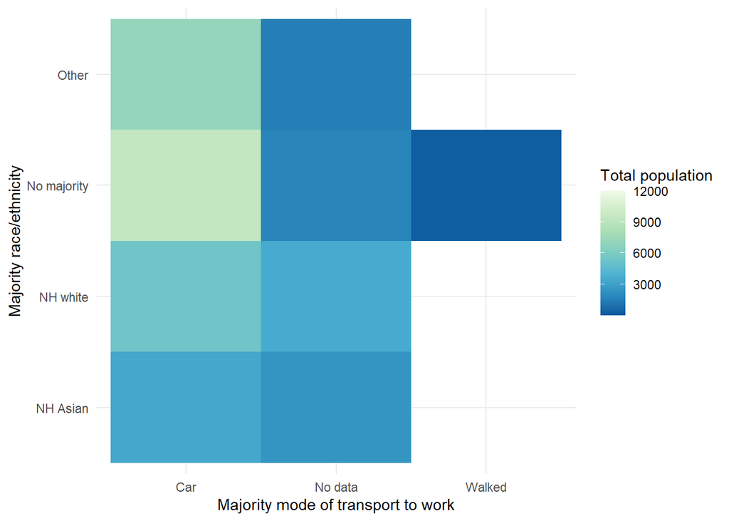

```r
ggplot(HI_tracts,
       aes(x = majority_transport,
           y = majority_race_eth,
           fill = tot_pop)) +
       geom_tile() +
      scale_x_discrete(name = "Majority mode of transport to work",
                       labels = c("Car",
                                  "No data",
                                  "Walked")) +
      scale_y_discrete(name = "Majority race/ethnicity",
                       labels = c("NH Asian",
                                  "NH white",
                                  "No majority",
                                  "Other")) +
      scale_fill_distiller(palette = "GnBu") +
      labs(fill = "Total population") +
      theme_minimal()
```

## Plot 7

Plot 7 shows a scatter plot on the polar coordinate system of median income vs. total population within a tract.

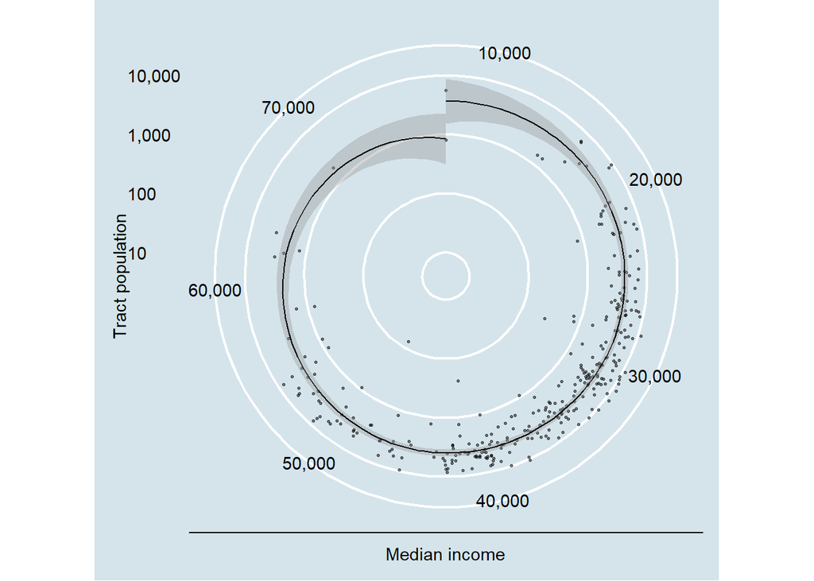

```r
ggplot(HI_tracts,
       aes(x = med_income,
           y = tot_pop)) +
  geom_point(alpha = 0.5, size = 0.5) +
  stat_smooth(color = "black", linetype = 1, size = 0.5) +
  scale_x_continuous(labels = scales::comma,
                     name = "Median income",
                     breaks = seq(0, 80000, by = 10000)) +
  scale_y_continuous(name = "Tract population",
                     trans = "log",
                     breaks = c(10, 100, 1000, 10000),
                     labels = c("10", "100", "1,000", "10,000")) +
  coord_polar(theta = "x") +
  theme_economist()
```

## Plot 8

Plot 8 shows an area chart of percent of the median age within a tract.

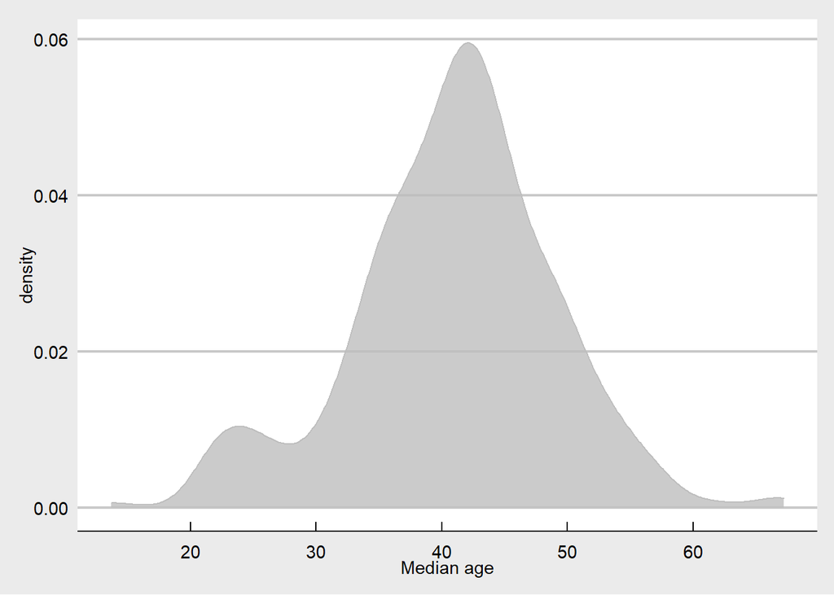

```r
ggplot(HI_tracts,
       aes(x=med_age)) +
  geom_density(fill="gray", color="gray", alpha=0.8) +
  scale_x_continuous(name = "Median age",
                     breaks = seq(0, 80, by = 10)) +
  theme_economist_white()
```

#Plot 9 Plot 9 shows a dot plot of whether a tract’s population is primarily native vs. foreign born by the total population of the tract

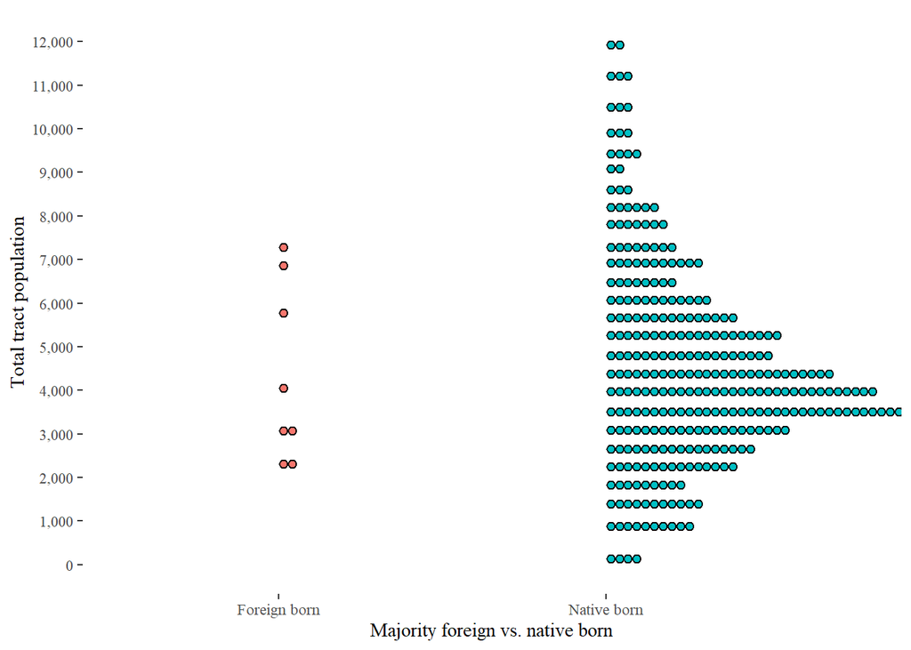

```r
 ggplot(HI_tracts, aes(x = factor(birth_native_foreign), y = tot_pop, fill = factor(birth_native_foreign))) +
    geom_dotplot(binaxis = "y", dotsize = 0.5) +
    scale_y_continuous(labels = scales::comma,
                       name = "Total tract population",
                       breaks = seq(0, 13000, by = 1000)) +
    scale_x_discrete(name = "Majority foreign vs. native born",
                       labels = c("Foreign born",
                                  "Native born")) +
    labs(fill = "Majority foreign vs. native born") +
    scale_fill_discrete(name = "Majority foreign vs. native born",
                       breaks=c("foreign born", "native born"),
                         labels=c("Foreign born", "native born"))+
  theme_tufte()
```

#Plot 10 For my last plot, I decided to try plotting all of my variables to see what happened.

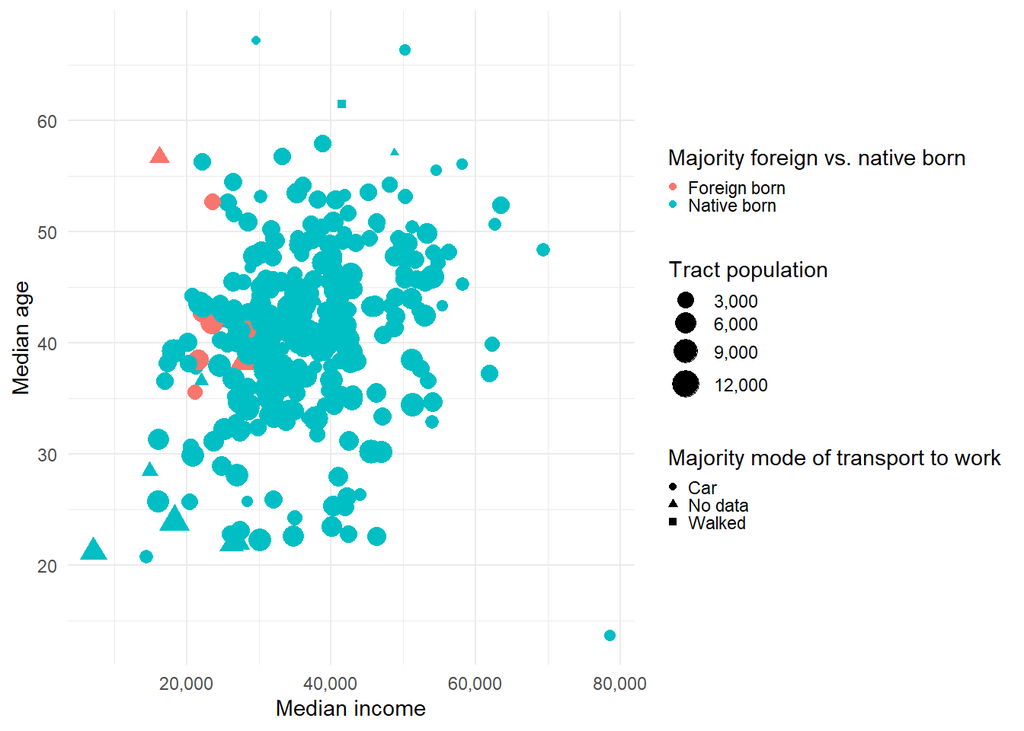

```r
ggplot(HI_tracts,
       aes(x = med_income,
           y = med_age,
           size = tot_pop,
           shape = majority_transport,
           color = birth_native_foreign,
           alpha = majority_race_eth)) +
  geom_point() +
  scale_size_continuous(labels = scales::comma,
                        name = "Tract population") +
  scale_x_continuous(labels = scales::comma,
                     name = "Median income",
                     breaks = seq(0, 80000, by = 20000))+
  scale_y_continuous(name = "Median age",
                     breaks = seq(10, 80, by = 10)) +
  scale_color_discrete(name = "Majority foreign vs. native born",
                       labels = c("Foreign born",
                                  "Native born")) +
  scale_alpha_discrete(name = "Majority race/ethnicity",
                         labels = "NH Asian",
                                  "NH white",
                                  "No majority",
                                  "Other") +
  scale_shape(name = "Majority mode of transport to work",
              labels = c("Car", "No data", "Walked")) +
  theme_minimal() +
  theme(legend.key.size = unit(0.1, "cm"))
```